# Project 1: Sentiment Analysis

# 1.Introduction

A Speech without emotion is like a body without soul. Presidential speeches, possibly the most viewed speeches, always deliver some important messages to not only American people but also the rest of world. Given their importance, presidents tended to use different emotions to achieve certain purposes, whether to demonstrate a certain personality or to gain trust from people. Thus, in this project, I am going to analyze all presidential speeches and find out how each persident uses emotion during their speeches.

# 2.Data Mining

In this section, I am going to extract President speeches from the internet and reconstruct them into tidy data which can be used directly for data analysis

## 2.1 Clearing Environment and Setting Work Directory

## 2.2 Installing Packages and Libraries

Install the necessary packages and library them

```r
packages.used=c("rvest","qdap","sentimentr", "gplots", "dplyr",
                "tm")
# check packages that need to be installed.
packages.needed=setdiff(packages.used,
                        intersect(installed.packages()[,1],
                                  packages.used))
# install additional packages
if(length(packages.needed)>0){
  install.packages(packages.needed, dependencies = TRUE)
}
# load packages
library("rvest")#
library("qdap")#
library("sentimentr")#
library("gplots")#
library("dplyr")#
source("../lib/plotstacked.R")
source("../lib/speechFuncs.R")
```

## 2.3 Loading Data

Extract the Inauguaration, Nomination and Farewell Speeches url separately from the internet and other information from excels

```r
### Inauguaral speeches
main.page <- read_html(x = "http://www.presidency.ucsb.edu/inaugurals.php")
inaug=f.speechlinks(main.page)
inaug=inaug[-nrow(inaug),] # remove the last line, irrelevant due to error.
#### Nomination speeches
main.page=read_html("http://www.presidency.ucsb.edu/nomination.php")
nomin <- f.speechlinks(main.page)
#### Farewell speeches
main.page=read_html("http://www.presidency.ucsb.edu/farewell_addresses.php")
farewell <- f.speechlinks(main.page)
inaug.list=read.csv("../data/inauglist.csv", stringsAsFactors = FALSE)
nomin.list=read.csv("../data/nominlist.csv", stringsAsFactors = FALSE)
farewell.list=read.csv("../data/farewelllist.csv", stringsAsFactors = FALSE)
names(inaug.list)[1]<- paste("President")
names(nomin.list)[1]<- paste("President")
names(farewell.list)[1]<- paste("President")
```

## 2.4 Data Manipulation

Combine all speeches and create a sentence list from all speeches corresponding to correct labels

```r
speech.list=rbind(inaug.list, nomin.list, farewell.list)
speech.list$type=c(rep("inaug", nrow(inaug.list)),
                   rep("nomin", nrow(nomin.list)),
                   rep("farewell", nrow(farewell.list)))
speech.url=rbind(inaug, nomin, farewell)
speech.list=cbind(speech.list, speech.url)
speech.list$fulltext=NA
for(i in seq(nrow(speech.list))) {
  text <- read_html(speech.list$urls[i]) %>% # load the page
    html_nodes(".displaytext") %>% # isloate the text
    html_text() # get the text
  speech.list$fulltext[i]=text
  # Create the file name
  filename <- paste0("../data/fulltext/",
                     speech.list$type[i],
                     speech.list$File[i], "-",
                     speech.list$Term[i], ".txt")
  sink(file = filename) %>% # open file to write
  cat(text)  # write the file
  sink() # close the file
}
speech1=paste(readLines("../data/fulltext/SpeechDonaldTrump-NA.txt",
                  n=-1, skipNul=TRUE),
              collapse=" ")
speech2=paste(readLines("../data/fulltext/SpeechDonaldTrump-NA2.txt",
                  n=-1, skipNul=TRUE),
              collapse=" ")
speech3=paste(readLines("../data/fulltext/PressDonaldTrump-NA.txt",
                  n=-1, skipNul=TRUE),
              collapse=" ")
Trump.speeches=data.frame(
  President=rep("Donald J. Trump", 3),
  File=rep("DonaldJTrump", 3),
  Term=rep(0, 3),
  Party=rep("Republican", 3),
  Date=c("August 31, 2016", "September 7, 2016", "January 11, 2017"),
  Words=c(word_count(speech1), word_count(speech2), word_count(speech3)),
  Win=rep("yes", 3),
  type=rep("speeches", 3),
  links=rep(NA, 3),
  urls=rep(NA, 3),
  fulltext=c(speech1, speech2, speech3)
)
speech.list=rbind(speech.list, Trump.speeches)
sentence.list=NULL
for(i in 1:nrow(speech.list)){
  sentences=sent_detect(speech.list$fulltext[i],
                        endmarks = c("?", ".", "!", "|",";"))
  if(length(sentences)>0){
    emotions=get_nrc_sentiment(sentences)
    word.count=word_count(sentences)
    # colnames(emotions)=paste0("emo.", colnames(emotions))
    # in case the word counts are zeros?
    emotions=diag(1/(word.count+0.01))%*%as.matrix(emotions)
    sentence.list=rbind(sentence.list,
                        cbind(speech.list[i,-ncol(speech.list)],
                              sentences=as.character(sentences),
                              word.count,
                              emotions,
                              sent.id=1:length(sentences)
                              )
    )
  }
}
sentence.list=
  sentence.list%>%
  filter(!is.na(word.count))
```

# 3. Emotion Analysis Based on Party

In this section, I am going to divide the data set based on their political parties and find out how emotions vary through different parties

## 3.1 Dividing the Dataset

There are five different political parties:

1. Fedralist: The first American political party. It existed from the early 1790s to 1816. Its remnants lasted into the 1820s. The Federalists called for a strong national government that promoted economic growth and fostered friendly relationships with Great Britain, as well as opposition to revolutionary France.
2. Democratic: One of the two major contemporary political parties in the United States. Today, the House Democratic caucus is composed mostly of progressives and centrists, with a smaller minority of conservative Democrats. The party’s philosophy of modern liberalism advocates social and economic equality, along with the welfare state. It seeks to provide government intervention and regulation in the economy.
3. Republican: One of the two major contemporary political parties in the United States. The Republican Party’s current ideology is American conservatism, which contrasts with the Democrats’ modern liberalism. The Republican Party’s platform involves support for free market capitalism, free enterprise, fiscal conservatism, a strong national defense, deregulation, and restrictions on labor unions.
4. Democratic-Republican: It believed that the Constitution was a “strict” document that clearly limited the powers of the federal government. Unlike the opposition Federalist Party, the Democratic-Republican Party contended that government did not have the right to adopt additional powers to fulfill its duties under the Constitution.
5. Whig: It supported the supremacy of the US Congress over the Presidency and favored a program of modernization, banking and economic protectionism to stimulate manufacturing. It appealed to entrepreneurs, planters, reformers and the emerging urban middle class, but had little appeal to farmers or unskilled workers.

```r
party <- unique(sentence.list$Party)
Fedralist <- sentence.list[sentence.list$Party==party[2],]
Fedralist <- Fedralist[!is.na(Fedralist$President),]
Democratic_Republican_Party <- sentence.list[sentence.list$Party==party[3],]
Democratic_Republican_Party <- Democratic_Republican_Party[!is.na(Democratic_Republican_Party$President),]
Democratic <- sentence.list[sentence.list$Party==party[4],]
Democratic <- Democratic[!is.na(Democratic$President),]
Whig <- sentence.list[sentence.list$Party==party[5],]
Whig <- Whig[!is.na(Whig$President),]
Republican <- sentence.list[sentence.list$Party==party[6],]
Republican <- Republican[!is.na(Republican$President),]
```

## 3.2 Barplot Comparison

Plot barplot to rank emotions based on their appearences.

```r
par(mfrow = c(3, 2))
emo.means=colMeans(select(Fedralist, anger:trust)>0.01)
col.use=c("red2", "darkgoldenrod1",
            "chartreuse3", "blueviolet",
            "darkgoldenrod2", "dodgerblue3",
            "darkgoldenrod1", "darkgoldenrod1")
barplot(emo.means[order(emo.means)], las=2, col=col.use[order(emo.means)], horiz=T, main="Fedralist")
emo.means=colMeans(select(Democratic, anger:trust)>0.01)
col.use=c("red2", "darkgoldenrod1",
            "chartreuse3", "blueviolet",
            "darkgoldenrod2", "dodgerblue3",
            "darkgoldenrod1", "darkgoldenrod1")
barplot(emo.means[order(emo.means)], las=2, col=col.use[order(emo.means)], horiz=T, main="Democratic")
```

```r
emo.means=colMeans(select(Democratic_Republican_Party, anger:trust)>0.01)
col.use=c("red2", "darkgoldenrod1",
            "chartreuse3", "blueviolet",
            "darkgoldenrod2", "dodgerblue3",
            "darkgoldenrod1", "darkgoldenrod1")
barplot(emo.means[order(emo.means)], las=2, col=col.use[order(emo.means)], horiz=T, main="Democratic_Republican_Party")
emo.means=colMeans(select(Whig, anger:trust)>0.01)
col.use=c("red2", "darkgoldenrod1",
            "chartreuse3", "blueviolet",
            "darkgoldenrod2", "dodgerblue3",
            "darkgoldenrod1", "darkgoldenrod1")
barplot(emo.means[order(emo.means)], las=2, col=col.use[order(emo.means)], horiz=T, main="Whig")
```

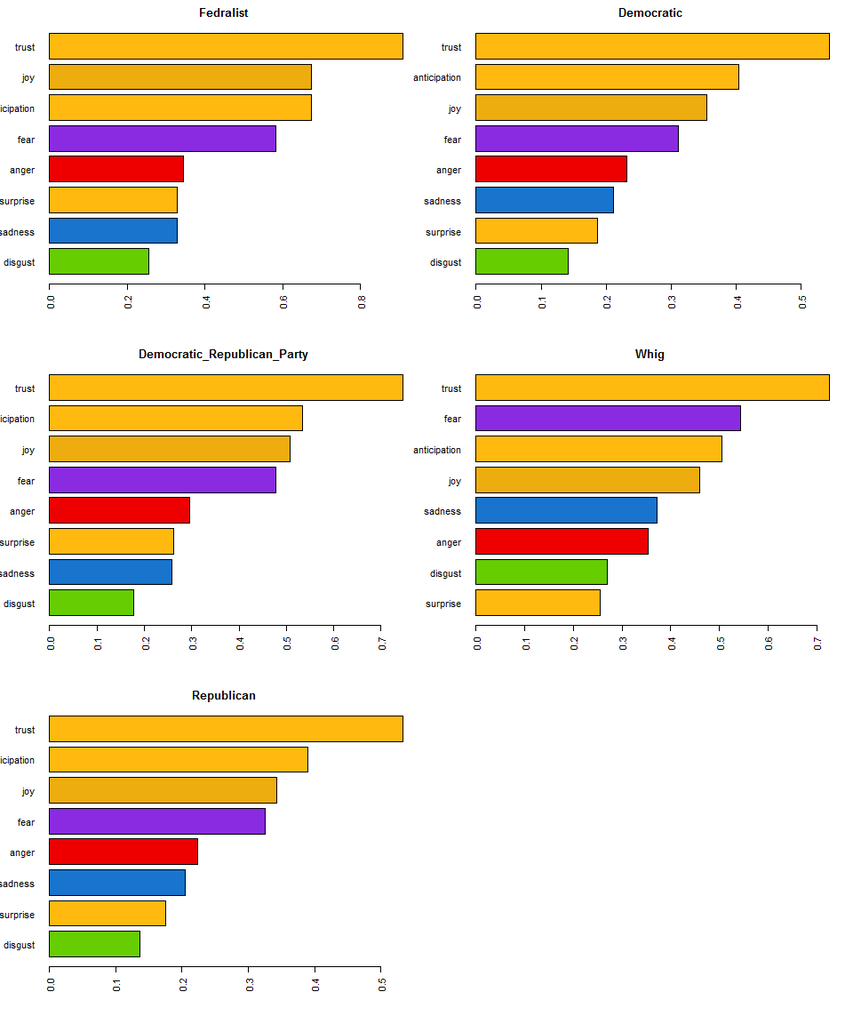

```r
emo.means=colMeans(select(Republican, anger:trust)>0.01)
col.use=c("red2", "darkgoldenrod1",
            "chartreuse3", "blueviolet",
            "darkgoldenrod2", "dodgerblue3",
            "darkgoldenrod1", "darkgoldenrod1")
barplot(emo.means[order(emo.means)], las=2, col=col.use[order(emo.means)], horiz=T, main="Republican")
```

By comparing barplots, we can clearly see some similarities and differences.

## 3.3 Heat Map Comparison

Plot heatmap of correlation values. Red indicates positive correlation and blue indicates negative correlation.

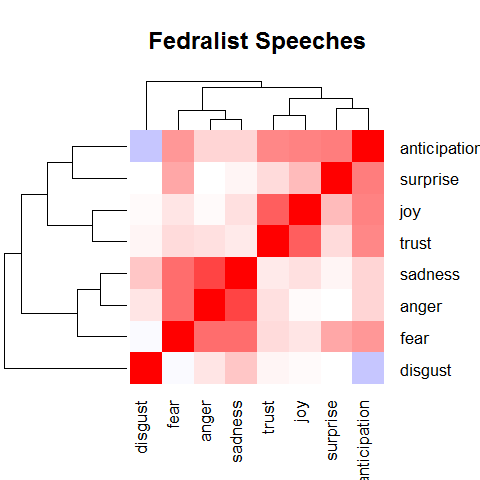

```r
par(mfrow = c(3, 2))
heatmap.2(cor(sentence.list%>%filter(Party=="Fedralist")%>%select(anger:trust)),
          scale = "none",
          col = bluered(100), , margin=c(6, 6), key=F,
          trace = "none", density.info = "none", main = "Fedralist Speeches")
```

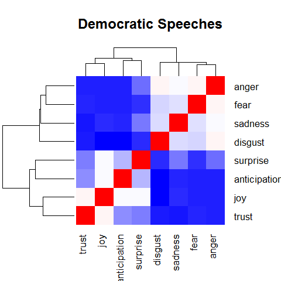

```r
heatmap.2(cor(sentence.list%>%filter(Party=="Democratic")%>%select(anger:trust)),
          scale = "none",
          col = bluered(100), , margin=c(6, 6), key=F,
          trace = "none", density.info = "none", main = "Democratic Speeches")
```

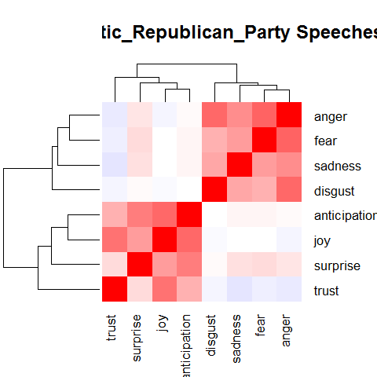

```r
heatmap.2(cor(sentence.list%>%filter(Party==party[3])%>%select(anger:trust)),
          scale = "none",
          col = bluered(100), , margin=c(6, 6), key=F,
          trace = "none", density.info = "none", main = "Democratic_Republican_Party Speeches")
```

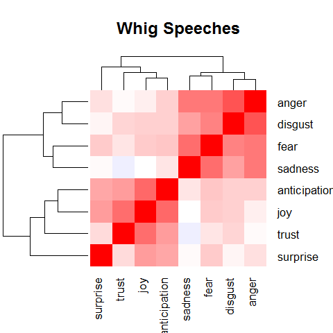

```r
heatmap.2(cor(sentence.list%>%filter(Party=="Whig")%>%select(anger:trust)),
          scale = "none",
          col = bluered(100), , margin=c(6, 6), key=F,
          trace = "none", density.info = "none", main = "Whig Speeches")
```

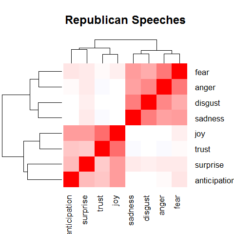

```r
heatmap.2(cor(sentence.list%>%filter(Party=="Republican")%>%select(anger:trust)),
          scale = "none",
          col = bluered(100), , margin=c(6, 6), key=F,
          trace = "none", density.info = "none", main = "Republican Speeches")
```

By comparing heat maps, we can tell that emotions of five parties except democratic share the same pattern: positive and negative emotions are correlated with themselves but not with each other. This indicates that their speeches normally contained both emotions. However, in Democratic speeches, positive and negative emotions are negatively correlated with each other which means that their speeches were either positive or negative. This pattern reflects that part of Democrats are extremists.

# 4. Emotion Analysis Based on Term

In this section, I am going to filter the Presidents who had two terms and divide their speeches into first-term and second-term speeches. Then, I will find out how emotion vary from their first term to second term.

## 4.1 Dividing the Dataset

Scrap the speeches of Presidents who had two terms

```r
termtwo <-speech.list[which(speech.list$Term==2)-1,]
unique.list=NULL
for(i in 1:nrow(termtwo)){
  sen=sent_detect(termtwo$fulltext[i],
                        endmarks = c("?", ".", "!", "|",";"))
  if(length(sen)>0){
    emotions=get_nrc_sentiment(sen)
    word.count=word_count(sen)
    # colnames(emotions)=paste0("emo.", colnames(emotions))
    # in case the word counts are zeros?
    emotions=diag(1/(word.count+0.01))%*%as.matrix(emotions)
    unique.list=rbind(unique.list,
                        cbind(termtwo[i,-ncol(termtwo)],
                              sen=as.character(sen),
                              word.count,
                              emotions,
                              sent.id=1:length(sen)
                        )
    )
  }
}
unique.list=
  unique.list%>%
  filter(!is.na(word.count))
```

Scrap their second-term speeches

```r
Second_term <- sentence.list[sentence.list$Term==2,]
Second_term <- Second_term[!is.na(Second_term$President),]
```

## 4.2 Barplot Comparison

Barplots did not display any differences, so I ignored this comparison

## 4.3 Heat Map Comparison

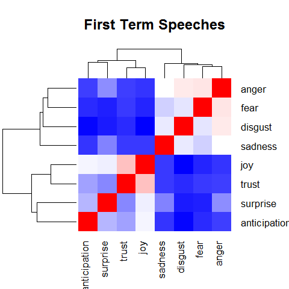

```r
heatmap.2(cor(unique.list%>%filter(Term==1)%>%select(anger:trust)),
          scale = "none",
          col = bluered(100), , margin=c(6, 6), key=F,
          trace = "none", density.info = "none", main = "First Term Speeches")
```

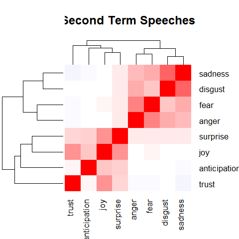

```r
heatmap.2(cor(sentence.list%>%filter(Term==2)%>%select(anger:trust)),
          scale = "none",
          col = bluered(100), , margin=c(6, 6), key=F,
          trace = "none", density.info = "none", main = "Second Term Speeches")
```

By comparing heat map, we can see that first-term speeches appears to be more extreme than the second-term speeches. Intuitively, POTUS was less experienced in their first term which made them less sophisticated in terms of making speeches.

# 5. Emotion Analysis Based on Win or Not

In this section, I am going to divide the nomination speeches into win and loss speeches based on the nomination results. Then, I will find out the emotion difference between them.

## 5.1 Dividing the Dataset

Divide the nomination speeches into win and loss speeches

```r
win_speech <- Nomination[Nomination$Win=="Yes",]
win_speech <- win_speech[!is.na(win_speech$President),]
lose_speech <- Nomination[Nomination$Win=="No",]
lose_speech <- lose_speech[!is.na(lose_speech$President),]
```

## 5.2 Barplot Comparison

Barplots did not display any differences, so I ignored this comparison

## 5.3 Heat Map Comparison

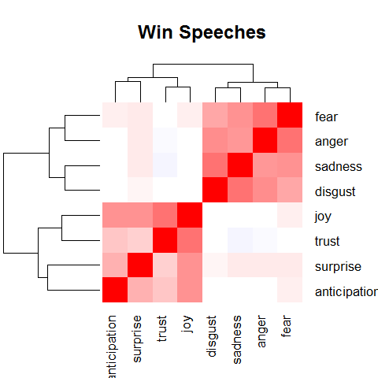

```r
heatmap.2(cor(sentence.list%>%filter(Win=="Yes")%>%select(anger:trust)),
          scale = "none",
          col = bluered(100), , margin=c(6, 6), key=F,
          trace = "none", density.info = "none", main = "Win Speeches")
```

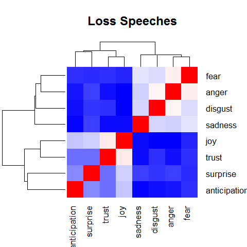

```r
heatmap.2(cor(sentence.list%>%filter(Win=="No")%>%select(anger:trust)),
          scale = "none",
          col = bluered(100), , margin=c(6, 6), key=F,
          trace = "none", density.info = "none", main = "Loss Speeches")
```

By comparing the heat maps, we can see that loss speeches appears to be more extreme than win speeches. Based on the nomination result, we can assume that loss speeches delivered a less sophisticated impression to voters which made them favor other candidates.

# 6 Discussion

In this project, I only include the meaningful results. I also divided the data set based on type, length and date of all presidential speeches and performed the same sentimental analysis. However, nothing interesting came out.

In addition, the intuitive explanation of all patterns that I found are limited. There are definitely other historical reasons that influence the pattern.